# GeoMX batch effect

# set up environment (Run whole chunk)

```r
# Load the packages
library(standR)
library(SpatialExperiment)
library(limma)
library(scater)
library(ExperimentHub)
library(ggalluvial)
require(FNN)
library(kBET)
library(Seurat)
```

# Input expression matrix and metadata (Action required for user)

```r
# read in expression
Raw_exp_mat <- read.csv("/bmbl_data/yuzhou/collaborative/Sizun_lab/EBV_project/Code/GitHubBatchEffectRemoval/GeoMXBatchCorrection/data/Masked_subsample_rawexp.csv",row.names = 1)

meta_df <- read.csv("/bmbl_data/yuzhou/collaborative/Sizun_lab/EBV_project/Code/GitHubBatchEffectRemoval/GeoMXBatchCorrection/data/Masked_subsample_metadata.csv",row.names = 1)
# how expression matrix looks like
Raw_exp_mat[1:5,1:5]
```

```
##       sample1 sample2 sample3 sample4 sample5
## A2M        36      99      63      30      25
## NAT2       19      60      38      17      18
## ACADM      21      84      53      29      13
## ACADS      28      99      67      34      21
## ACAT1      17      54      41      13      18
```

```r
# how metadata dataframe looks like
meta_df[1:5,]
```

```
##         Sample_ID Disease celltype patientID
## sample1   sample1     pos    Tumor  Patient1
## sample2   sample2     pos   CD4mem  Patient1
## sample3   sample3     pos CD4naive  Patient1
## sample4   sample4     pos   CD8mem  Patient1
## sample5   sample5     pos CD8naive  Patient1
```

# Predefined some functions for calculating silhoutte and Kbet score (Run whole chunk)

```r
# Silhoutte
cal_sil <- function(se.object = spe.list[[names(spe.list)[1]]],
                    #obj.name = names(spe.list)[1],
                    batch.name = "patient"){
  data <- assay(se.object,i = 2)
  # find HVG
  dec <-scran:: modelGeneVar(data)
  top_genes <- scran::getTopHVGs(dec, n = 1000)
  data_hvg <- t(data[rownames(data) %in% top_genes,])
  #
  batch <- colData(se.object)[,batch.name]
  pca.data.f <- gmodels::fast.prcomp(data_hvg, center=TRUE)
  dd <- as.matrix(dist(pca.data.f$x[, 1:10]))
  batch.silhouette <- summary(cluster::silhouette(as.numeric(factor(batch,
                                                                    levels = sort(unique(batch)),
                                                                    labels = 1:length(sort(unique(batch))))), dd))$avg.width
  return(batch.silhouette)
}

# kBET
cal_kbet <- function(se.object = spe.list[[names(spe.list)[1]]],
                    # obj.name = names(spe.list)[1],
                     batch.name = "patient"){
  data <- assay(se.object,i = 2)
  # find HVG
  dec <-scran:: modelGeneVar(data)
  top_genes <- scran::getTopHVGs(dec, n = 1000)
  data_hvg <- t(data[rownames(data) %in% top_genes,])
  #
  batch <- colData(se.object)[,batch.name]
  k0=floor(mean(table(batch))) #neighbourhood size: mean batch size
  knn <- get.knn(data_hvg, k=k0, algorithm = 'cover_tree')
  batch.estimate <- kBET(data_hvg, batch, k = k0, knn = knn,plot = F)
  return(batch.estimate)
}
```

# Set up benchmarking parameter for RUV4 functions (Action required for user)

To accelerate the execution speed of the tutorial, we only consider four types of normalization here. Users will need to set the remaining parameters themselves, including wanted variable, unwanted variable, number of negative control genes, and k from RUV4.

- factors: it indicate wanted factors and unwanted factors, i.e. the biological variation to keep;
- NCGs: the list of negative control genes detected using the function findNCGs;
- k: the number of unwanted factors to use. Based on RUV’s documentation, it is suggest to use the smallest k possible where the observed technical variation is no longer observed.

```r
# define unwanted factor
unwantedVariable <- c("patientID")
# define wanted factor
WantedVariable <- c("Disease","celltype")
normalization_methods <- c("TMM", "CPM", "upperquartile", "sizefactor")
# number of negative control gene
findNCG_topn <- seq(from = 100, to = 100, by = 200)
# k of RUV4 (The number of unwanted factors to use. Can be 0. This is required for the RUV4 method.)
BatchCorrection_k <- seq(from = 3, to = 3, by = 2)
# show the number of combinations
print(paste0("Combination Parameter Number: ",length(BatchCorrection_k)*length(findNCG_topn)*length(normalization_methods)))
```

```
## [1] "Combination Parameter Number: 4"
```

# Run Benchmarking (run whole chunk)

```r
# create spatial Experiment obj
spe <- SpatialExperiment(assay = list(counts = Raw_exp_mat), colData = meta_df)
spe.list <- list()
# Total number of iterations
total_iterations <- length(normalization_methods) * length(findNCG_topn) * length(BatchCorrection_k)

# Initialize progress bar
progress <- txtProgressBar(min = 0, max = total_iterations, style = 3)
iteration_count <- 0

for (n_m in 1:length(normalization_methods)) {
  tmp_n_m <- normalization_methods[n_m]
  tmp_spe <- geomxNorm(spe, method = tmp_n_m)
  if(tmp_n_m == "CPM"){tmp_spe <- scater::logNormCounts(spe)}

  for (topn in 1:length(findNCG_topn)) {
    tmp_topn <- findNCG_topn[topn]
    #### here need to set up the batch factor based on meta data
    tmp_spe <- findNCGs(tmp_spe, batch_name = unwantedVariable, top_n = tmp_topn)

    for (k in 1:length(BatchCorrection_k)) {
      tmp_k <- BatchCorrection_k[k]
      # [to do] change factors to biological variation remain based on meta data
      # here to setup wanted biology variable
      tmp_spe <- geomxBatchCorrection(tmp_spe, factors = WantedVariable,
                                      NCGs = metadata(tmp_spe)$NCGs, k = k)
      tmp_name <- paste0(tmp_n_m, "-nNCG_", tmp_topn, "-k_", tmp_k)
      spe.list <- c(spe.list, tmp_spe)
      names(spe.list)[length(spe.list)] <- tmp_name

      # Update progress bar
      iteration_count <- iteration_count + 1
      setTxtProgressBar(progress, iteration_count)
    }
  }
}
# Close progress bar
close(progress)
```

# evaluation using silouette and Kbet (Run whole chunk)

```r
# run for each of factor, including patientID (batch confounder), celltype (biological variation), and Disease (biological variation)
batch.name = c(unwantedVariable, WantedVariable)
sil_score_list <- list()
k_bet_list <- list()
# progress bar
total_iterations <- length(spe.list)*length(batch.name)

# Initialize progress bar
progress <- txtProgressBar(min = 0, max = total_iterations, style = 3)
iteration_count <- 0
for (i in 1:length(spe.list)){
  se.object = spe.list[[names(spe.list)[i]]]
  obj.name = names(spe.list)[i]
  for (j in 1:length(batch.name)){
    sil_score <- cal_sil(se.object = se.object, batch.name = batch.name[j] )
    k_bet.obj <- cal_kbet(se.object = se.object, batch.name = batch.name[j] )
    sil_score_list <- c(sil_score_list, sil_score)
    k_bet_list <- c(k_bet_list, mean(k_bet.obj$stats$kBET.observed))
    names(sil_score_list)[length(sil_score_list)] <-  names(k_bet_list)[length(k_bet_list)] <- paste0(batch.name[j],"_",obj.name)
    # Update progress bar
    iteration_count <- iteration_count + 1
    setTxtProgressBar(progress, iteration_count)
  }
}
# evaluation of all factors
# minimize unwanted variance
unwantedVariable_df <- matrix(rep(NA,length(unwantedVariable)*length(spe.list)*5),ncol =length(unwantedVariable)*5 )

unwantedVariable_combinations <- expand.grid(unwantedVariable,  c("_sil","_kbet","_Silrank","_kbetrank","_MeanRank"))

colnames(unwantedVariable_df) <- paste0(unwantedVariable_combinations$Var1, unwantedVariable_combinations$Var2)

rownames(unwantedVariable_df) <-  names(spe.list)
for (i in 1:length(unwantedVariable)){
  tmp_unwantedVariable <- unwantedVariable[i]
  tmp_kbet_name_vec <- grep(tmp_unwantedVariable,(names(k_bet_list)),value = F)
  tmp_kbet <-  unlist(k_bet_list[tmp_kbet_name_vec])
  tmp_sil_name_vec <- grep(tmp_unwantedVariable,(names(sil_score_list)),value = F)
  tmp_sil <-  unlist(sil_score_list[tmp_sil_name_vec])

  #
  names(tmp_sil) <- names(tmp_kbet) <- gsub(paste0("^",tmp_unwantedVariable,"_"),"",names(tmp_sil))
  tmp_unwantedVariable_kbet_rank <- rank(tmp_kbet)
  tmp_unwantedVariable_sil_rank <- rank(tmp_sil)
  # mean rank of batch
  tmp_unwantedVariable_kbet_rank <- tmp_unwantedVariable_kbet_rank[rownames(unwantedVariable_df)]
  tmp_unwantedVariable_sil_rank <- tmp_unwantedVariable_sil_rank[rownames(unwantedVariable_df)]
  unwantedVariable_df[,paste0(tmp_unwantedVariable,c("_sil"))] <- as.numeric(tmp_sil)
  unwantedVariable_df[,paste0(tmp_unwantedVariable,c("_kbet"))] <- as.numeric(tmp_kbet)
  unwantedVariable_df[,paste0(tmp_unwantedVariable,c("_Silrank"))] <- as.numeric(tmp_unwantedVariable_sil_rank)
  unwantedVariable_df[,paste0(tmp_unwantedVariable,c("_kbetrank"))] <- as.numeric(tmp_unwantedVariable_kbet_rank)
  # cal mean rank of sil and kbet
  unwantedVariable_df[,paste0(tmp_unwantedVariable,c("_MeanRank"))] <- rowSums(unwantedVariable_df[,c(paste0(tmp_unwantedVariable,c("_Silrank")),
                                                                                                paste0(tmp_unwantedVariable,c("_kbetrank")))])/2
}

# Maximize wanted variance
WantedVariable_df <- matrix(rep(NA,length(WantedVariable)*length(spe.list)*5),ncol =length(WantedVariable)*5 )
WantedVariable_combinations <- expand.grid(WantedVariable, c("_sil","_kbet","_Silrank","_kbetrank","_MeanRank"))

colnames(WantedVariable_df) <- paste0(WantedVariable_combinations$Var1, WantedVariable_combinations$Var2)
rownames(WantedVariable_df) <-  names(spe.list)
for (i in 1:length(WantedVariable)){
  tmp_WantedVariable <- WantedVariable[i]
  tmp_kbet_name_vec <- grep(tmp_WantedVariable,(names(k_bet_list)),value = F)
  tmp_kbet <-  unlist(k_bet_list[tmp_kbet_name_vec])
  tmp_sil_name_vec <- grep(tmp_WantedVariable,(names(sil_score_list)),value = F)
  tmp_sil <-  unlist(sil_score_list[tmp_sil_name_vec])

  #
  names(tmp_sil) <- names(tmp_kbet) <- gsub(paste0("^",tmp_WantedVariable,"_"),"",names(tmp_sil))
  tmp_WantedVariable_kbet_rank <- rank(-tmp_kbet)
  tmp_WantedVariable_sil_rank <- rank(-tmp_sil)
  # mean rank of batch
  tmp_WantedVariable_kbet_rank <- tmp_WantedVariable_kbet_rank[rownames(WantedVariable_df)]
  tmp_WantedVariable_sil_rank <- tmp_WantedVariable_sil_rank[rownames(WantedVariable_df)]
  WantedVariable_df[,paste0(tmp_WantedVariable,c("_sil"))] <- as.numeric(tmp_sil)
  WantedVariable_df[,paste0(tmp_WantedVariable,c("_kbet"))] <- as.numeric(tmp_kbet)
  WantedVariable_df[,paste0(tmp_WantedVariable,c("_Silrank"))] <- as.numeric(tmp_WantedVariable_sil_rank)
  WantedVariable_df[,paste0(tmp_WantedVariable,c("_kbetrank"))] <- as.numeric(tmp_WantedVariable_kbet_rank)
  WantedVariable_df[,paste0(tmp_WantedVariable,c("_MeanRank"))] <- rowSums(WantedVariable_df[,c(paste0(tmp_WantedVariable,c("_Silrank")),
                                                                                               paste0(tmp_WantedVariable,c("_kbetrank")))])/2
}
```

# select your parameters (Action required for user)

```r
# merge results of wanted variable and unwanted variable
merge_res <- cbind.data.frame(unwantedVariable_df,WantedVariable_df)
merge_res <- merge_res[,grep("_MeanRank",colnames(merge_res))]
merge_res$overall_rank <- rowSums(merge_res[,grep("_MeanRank",colnames(merge_res))])/length(merge_res[,grep("_MeanRank",colnames(merge_res))])
merge_res <- merge_res[order(merge_res$overall_rank),]
print(merge_res)
```

```
##                            patientID_MeanRank Disease_MeanRank
## TMM-nNCG_100-k_3                          2.0              2.0
## upperquartile-nNCG_100-k_3                2.0              2.5
## CPM-nNCG_100-k_3                          2.5              2.5
## sizefactor-nNCG_100-k_3                   3.5              3.0
##                            celltype_MeanRank overall_rank
## TMM-nNCG_100-k_3                        2.25     2.083333
## upperquartile-nNCG_100-k_3              2.50     2.333333
## CPM-nNCG_100-k_3                        2.50     2.500000
## sizefactor-nNCG_100-k_3                 2.75     3.083333
```

# Validation using seurat package for checking the batch visually and export results

```r
# For "TMM", "upperquartile", "sizefactor", method, please remove # and run tmp_spe <- geomxNorm(spe, method = "upperquartile")

# for using CPM, please use the following tmp_spe <- scater::logNormCounts(spe)
# tmp_spe <- geomxNorm(spe, method = "upperquartile")
tmp_spe <- scater::logNormCounts(spe)
# top_n = numebr of negative control gene
tmp_spe <- findNCGs(tmp_spe, batch_name = unwantedVariable, top_n = 1500)
# k is previous tuned parameter
tmp_spe <- geomxBatchCorrection(tmp_spe, factors = WantedVariable,
                                NCGs = metadata(tmp_spe)$NCGs, k = 11)
dec <-scran:: modelGeneVar(tmp_spe)
top_genes <- scran::getTopHVGs(dec, n = 1000)
# exp_mat is the post-correct expression matrix
exp_mat <- assay(tmp_spe,i = 2)
# write the expression matrix
write.csv(exp_mat,file = "EBV_chl_batchcorrected-CPM-nNCGH_1500-K_11.csv",quote = F)

# using Seurat to visualize the geomx sample relations
Seurat_obj <- CreateSeuratObject(exp_mat[top_genes,])
Seurat_obj <- AddMetaData(object = Seurat_obj,metadata = as.data.frame(colData(tmp_spe)))
Seurat_obj  <- FindVariableFeatures(Seurat_obj,nfeatures = 1000)
Seurat_obj  <- ScaleData(Seurat_obj)
Seurat_obj <- RunPCA(Seurat_obj)
```

```
## PC_ 1
## Positive:  RPS23, RPS28, RPL37A, RPL27A, RPS17, RPL26, RPL9, RPL36A, RPS6, RPS2
##     RPS14, RPS27A, RPS29, EEF1D, RPS19, RPL24, RPL19, RPL18, RPLP2, RPS12
##     RPS20, RPS8, RPL41, RPL32, RPL8, TLE5, RPL35A, RPL15, NPIPB6, RPL18A
## Negative:  SPANXA2, CYP2W1, EBER1, GAGE10, XAGE1A, SPANXC, ISOC1, SSX3, GAGE1, FAM90A1
##     CT47A10, CTNND2, MZT2B, BHLHE23, GADD45A, FAM236B, FERD3L, PABPC1L2A, TM4SF4, CCL13
##     SSX1, CT45A1, XAGE5, SSX5, ATXN3L, CENPVL3, SPANXN5, C5orf38, OR7E24, SSX4B
## PC_ 2
## Positive:  KIF4B, PRMT8, CXCR5, PIK3CD, MAMDC2, GZMA, PTPRCAP, CYTIP, CCL5, CR2
##     SEPTIN1, ATP2A3, FDCSP, NKG7, SLC6A18, VPREB3, ISG20, TRIM64B, P2RX5, EVL
##     EPB41, MYO5B, RHOH, CD79A, STK17B, SP140, IL2RB, RALGPS2, UBXN10, ATP8A1
## Negative:  CST3, LYZ, SAT1, SERPINA1, C1QC, A2M, CALHM6, SPARCL1, CTSC, APOC1
##     RASSF4, C1QA, CD74, C1QB, APOE, UBD, CPVL, ATG3, CTSB, DNASE1L3
##     COL4A2, PLVAP, CTSH, FGL2, ENG, CCL14, CTSS, WARS1, ACKR1, VWF
## PC_ 3
## Positive:  PIWIL4, REP15, OVOL2, SLC5A1, CHGB, DTNA, CDX2, FBXO2, SLC6A18, CCL18
##     DNAJB13, KRTAP1-1, C1QB, GPR82, HRH3, CDON, SIGLEC1, CHIT1, LRRC30, CLRN1
##     PM20D1, TTC32, CHI3L1, UPK3BL2, WFDC8, TEX14, F10, ITK, ERVW-1, C1QA
## Negative:  HLA-DQA1, TSPAN13, FOS, CCL22, CCL17, HLA-G, DNASE1L3, ACKR1, JCHAIN, VWF
##     HBA2, FDCSP, TSPAN7, FCER2, CD83, SWAP70, ID1, VPREB3, TXNDC5, CD79A
##     ADAM19, CCL14, A2M, HLA-DQB1, CR2, IRF8, IGKC, SPP1, SPARCL1, H2AC14
## PC_ 4
## Positive:  C7, LIPA, P2RY8, PRMT8, IGLL5, IGKC, TXNDC5, IGHG1, XRCC2, TIMP3
##     CTSB, IGHA1, USP17L17, IGHM, C1QA, MSR1, ENG, SPATA31A6, CCL5, IGHG4
##     JCHAIN, C1QC, XBP1, C1QB, TGM2, IGHG2, CST3, CCL3L3, SPATA31A5, B2M
## Negative:  FABP1, CCL17, CCL22, ZBED2, NFYA, MAF, THNSL2, H2BC14, NFKB2, CD70
##     CTLA4, HPGDS, PLA2G2D, EEF1A2, EIF1AY, DHRS2, TRDC, ADGRG4, ACOT11, LRRC8E
##     CCR7, PSD, LAMB3, EIF3I, KRTDAP, CD69, MTA2, DDX4, H3C15, UXT
## PC_ 5
## Positive:  MMP9, TIMD4, SYNDIG1, DDX4, WDR1, TESPA1, ENPP2, AQP1, DDX3Y, KRTDAP
##     MILR1, SMARCA2, SF3A1, GPSM3, USP34, C17orf98, RASSF4, CHMP7, HLA-G, PRMT8
##     HIPK1, H2AC7, RBMY1J, ZNF609, EIF3L, FABP7, LIPA, CHD3, USP9Y, CTNND2
## Negative:  MZB1, ALOX5, XBP1, IGHM, IGKC, PIM2, IGHG1, EEF1A2, P2RY8, IGHG2
##     IGHG4, HPSE2, SSR4, IGHG3, BANK1, FCER2, CD19, H3C8, TXNDC5, SNX29
##     MS4A1, VSIG4, IGLL5, NKG7, OVOL2, ARSK, GABRA3, KIF4B, RHBDL1, CD79A
```

```r
Seurat_obj <- RunUMAP(Seurat_obj,dims = 1:20)
```

```
## 12:52:58 Found 2 connected components, falling back to 'spca' initialization with init_sdev = 1
## 12:52:58 PCA: 2 components explained 74.02% variance
## 12:52:58 Scaling init to sdev = 1
```

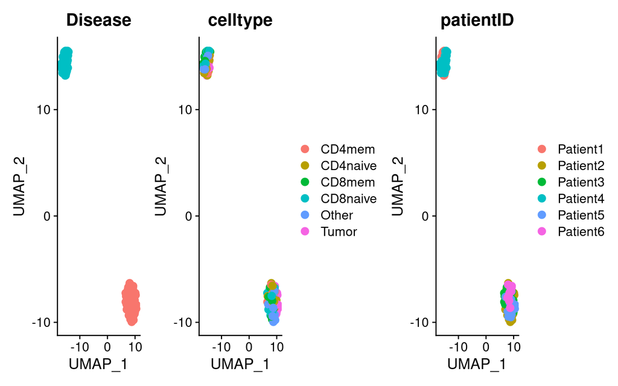

```r
# customize the plot panel based on the variables
p1 <- DimPlot(Seurat_obj,group.by = WantedVariable[1],pt.size = 3)+ theme(legend.position="none")
p2 <- DimPlot(Seurat_obj,group.by = WantedVariable[2],pt.size = 3)
p3 <- DimPlot(Seurat_obj,group.by = unwantedVariable[1],pt.size = 3)
p1+p2+p3
```